# PART 2. 湾曲ウェブシステム

(BY W. F. McCOMBS)

## C11.30 湾曲ウェブシステムにおける対角引張 - はじめに

このタイプの構造は、軽金属構造の設計において重要な位置を占めている。構造設計者は、やや単純な平面ウェブシステムについて理解しているのと同様に、これについても十分に理解していなければならない。実際、ほとんどの航空機のせん断ウェブシステムは、平らではなく湾曲しており、現代の航空機の胴体がその代表的な例である。胴体の外板を完全に座屈しないようにするには、非常に厚い外板や、それを支持する密に配置された下部構造が必要となる。これは、座屈外板の配置と比較して、かなりの重量増加を招く。したがって、現代の戦闘機や輸送機における典型的な金属外板は、かなりの程度の外板座屈を伴いながら制限荷重および終局荷重を分担している。このため、湾曲ウェブシステムにおける対角引張効果を理解する必要があるのは明らかである。

## C11.31 一般的な議論

設計の詳細に入る前に、ウェブが座屈するときに湾曲ウェブシステムで何が起こるかについて一般的に議論することが役立つ。Fig. C11.29 に示すような円形（または楕円形）の断面形状を持つセミモノコック構造を考える。

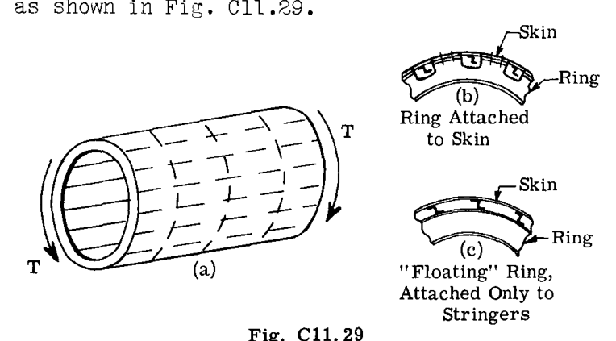

Fig. C11.29

この構造は、多数の軸方向部材（多数の場合は「ストリンガー」、3〜8本程度と少数である場合は「ロンジロン」と呼ばれる）から構成され、これらはフレームまたはリングによって支持され、外板で覆われている。リングは外板に取り付けられ、Fig. (b) のようにストリンガーを通すために「ノッチ」が設けられている場合もあれば、ストリンガーの完全に下に位置し、外板に取り付けられていない場合もある。後者の場合、Fig. (c) に示すように、これらは「フローティング」リングと呼ばれる。時として、両方のタイプのリングが存在することもある。この構造を平面ウェブビームと比較すると、ストリンガーはフランジに、リングは直立材（アップライト）に、外板はウェブに対応する。したがって、ストリンガーは軸荷重を支持（または抵抗）する。リングはストリンガーを支持し、「フローティング」タイプでない場合は、外板パネルをより短い長さに分割する。外板はせん断荷重を支持（または抵抗）する。

ここで、構造が Fig. C11.29 に示すような純ねじり $T$ を受けるものと仮定する。外板が座屈する前は、このねじりによって外板パネルに以下のよく知られた公式で与えられるせん断が生じる。

$$q = \frac{T}{2A}$$

外板のみが荷重を受ける。平面ウェブビームのアップライトの場合と同様に、リングには荷重がかからない。ストリンガーにも荷重はかからない。

しかし、ねじりが増加するにつれて、外板のせん断応力は最終的に臨界座屈応力よりも大きくなり、パネルは座屈する。それ以上のねじりの増加は、対角引張として担われなければならない。ねじりが座屈値を超えて増加すると、Fig. C11.30 に示すように、主に5つの現象が発生する。

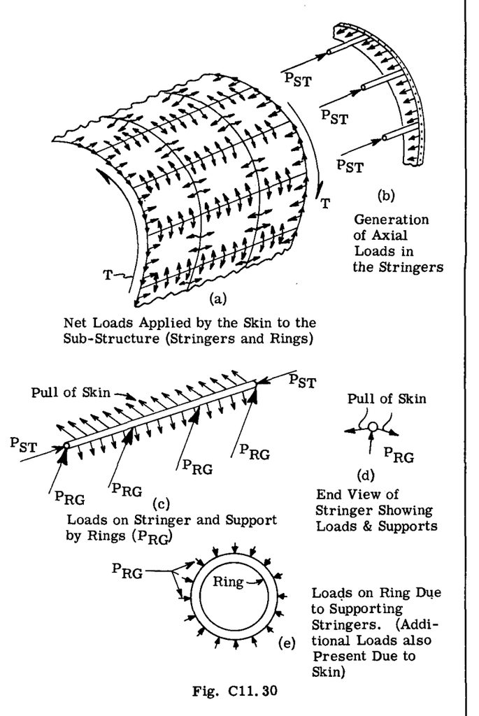

Fig. C11.30

1. 外板パネルは座屈し、外板に固定されたリング間で、元の湾曲した形状から平らになる。これにより、（リングから離れた場所で）多角形の断面が得られる。ただし、対角引張の角度は平面ウェブビームの角度よりも小さく、 $20^{\circ} - 30^{\circ}$ の範囲である。
2. 平面ウェブビームの場合と同様に、座屈した外板によって構造物の端部が引っ張られるため、ストリンガーは軸方向の荷重を受ける（Fig. C11.30b）。
3. ストリンガーはまた、支持リング間で内側に曲がる、あるいは「たわむ」傾向のある法線荷重を受ける（Fig. C11.30c）。
4. 支持リングは内向きの荷重を受け、これにより「フープ」圧縮状態になる。外板に固定されたリングの場合、この荷重はストリンガーと外板によって加えられるため、「分散」される。フローティングリングの場合、この荷重はストリンガーのみから加えられ、したがって点に集中する。この集中により、圧縮だけでなく、フローティングリング内に内部曲げモーメントも発生する。これは Fig. C11.30e に示されている。
5. 外板同士を接合する締結具や、外板を端部リングに固定する締結具は、せん断パネルタイプの荷重だけでなく、平面ウェブビームの場合と同様に法線荷重も受ける。また、対角座屈による外板の「ひだ」は、ストリンガーやリングの鋲線（リベットライン）を越えて広がろうとするため、リベットをこじ開けるように作用する。

ここで理解すべき重要なことは、純ねじりのみが加えられたにもかかわらず、ストリンガーやリングにはかなりの軸荷重が発生しているということである。そして、「フローティング」タイプのストリンガーやリングには、曲げモーメントさえも誘発されている。

ここで、ねじり荷重が加えられると同時に、Fig. C11.31 に示すように、増加する圧縮軸荷重 $P$ が同時に加えられていると仮定する。

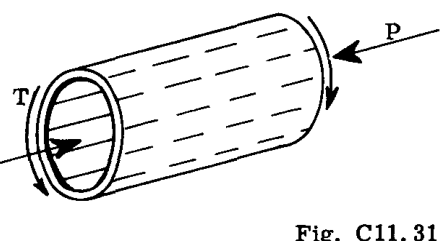

Fig. C11.31

$P$ の存在により、以下のことが発生する。

1. ストリンガーは当然、圧縮荷重 $P$ を負担しなければならず、これはストリンガー間で分割される。これを助けるいくつかの「有効」外板が存在する。
2. 目立ちにくいが非常に重要なのは、ねじり $T$ による対角引張荷重が、軸荷重 $P$ の存在によってかなり影響を受けるという事実である。 $T$ に対する $P$ が大きいほど、対角引張効果への影響は大きくなる。これは以下の通りである。
   1. 外板パネルは軸方向にも圧縮を受けるため、より低いねじり荷重で座屈するようになる。実際には、圧縮座屈とせん断座屈からなる「複合」座屈が存在する。これは後述の相互作用方程式から得ることができる。
   2. 臨界せん断座屈応力が低くなるため、対角引張係数 $k$ は大きくなる。
   3. $k$ に依存するすべての対角引張効果が増大する。これらには、ストリンガーに誘発される軸荷重、ストリンガーを内側に曲げる法線荷重、リングに誘発される荷重、および締結具が受ける荷重が含まれる。
   4. 対角引張の角度は大きくなり、 $45^{\circ}$ に近くなる。

したがって、圧縮の効果は対角引張による荷重を増加させることであることがわかる。

ここで、圧縮の代わりに、軸荷重 $P$ が引張であると仮定する。この場合、 $T$ による対角引張の効果は減少する。

1. ストリンガーと外板は $P$ による引張を受け、これは対角引張による圧縮に対抗する。
2. 外板パネルは、せん断座屈する前により大きなせん断応力を負担することができる。実際、比較的少量の軸方向引張によって、後述するように、座屈を完全に防ぐことができる。
3. 対角引張係数 $k$ は小さくなる（座屈が発生しない場合はゼロ）。
4. $k$ に依存するすべての対角引張効果が減少し、対角引張角度は小さくなる。

最後に、軸荷重 $P$ の代わりに、Fig. C11.32 に示すように、ねじり $T$ と同時に曲げモーメント $M$ が加えられていると仮定する。

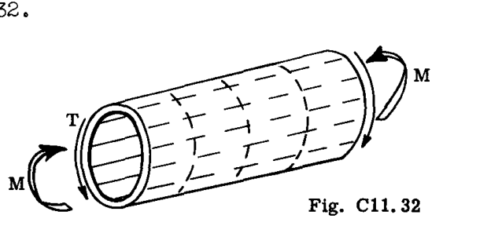

Fig. C11.32

この場合も、ねじりが微小な量から増加するにつれて、 $M$ も（軸荷重 $P$ の場合と同様に、 $M$ と $T$ の比が一定のまま）増加する。このとき、通常の曲げ理論 $f = \frac{Mz}{I}$ から、以下のことが発生する。

1. 中立軸より上にあるストリンガー（および外板）は圧縮荷重を受け、中立軸から離れるほど荷重は大きくなる。したがって、上部の外板パネルは、圧縮とせん断の複合作用により、より早期に座屈し、ストリンガーおよびリングに最大の対角引張荷重を発生させる。
2. 中立軸より下にある外板は、 $M$ によって生じる引張ひずみにより、より遅く座屈する（またはまったく座屈しない）。したがって、この領域のリングおよびストリンガーにおける対角引張効果は小さくなる（または存在しない）。
3. 中立軸付近の外板は、曲げによるひずみをほとんど受けることがなく、純ねじり $T$ の場合とほぼ同様に座屈し、同等の効果をもたらす。

実際の航空機構造（例えば胴体）では、加えられる荷重はより複雑である。単に加えられるねじりだけでなく、通常は垂直方向、そして場合によっては横方向の荷重群が存在し、これらはパネルごとに異なるせん断を発生させる。また、胴体に沿って変化する曲げモーメントだけでなく、着陸やカタパルト射出の要件などによる軸荷重も存在する。明らかに、これらすべてが計算を複雑にし、経験と判断が大きな助けとなるが、その進め方は基本的であり、以下に説明する。

N.A.C.A. は、対角引張状態の湾曲ウェブを持つ構造の設計システムを決定することを目的として、長年にわたり広範なプログラムを実施してきた。このシステムに関する理論は、平面ウェブビームの場合と同様に、Wagner らによって与えられ、多くのテスト結果から必要に応じて修正された。設計方法は Ref. (3) で詳細に議論されており、裏付けとなるテストプログラムは Ref. (4) に示されている。理論的な展開とテスト結果のより詳細な説明については、これらの文献を参照されたい。

前述のように、湾曲ウェブシステムは大きく2つのタイプに分類される。その一方は、外板（ウェブ）パネルが周方向の長さ $h$ よりも軸方向の長さ $d$ の方が長くなる配置を持つものである。これは、Fig. C11.33 に示すように、胴体における典型的なストリンガーシステムである。

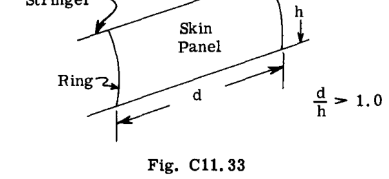

Fig. C11.33

すなわち、ストリンガー間隔 $h$ とリング間隔 $d$ の幾何学的形状は、以下のようになる。

$$\frac{d}{h} > 1.0$$

「フローティング」リングは外板に取り付けられていないため、間隔 $d$ を決定しない。

湾曲ウェブ構造の第2のタイプは、ロンジロンシステムと呼ばれる。その主な特徴は、外板パネルが周方向に長いことである。このタイプの構造は、典型的な胴体において、少数の軸方向部材（フェイルセーフ設計では最小3本、通常は4〜8本）と、多数の密に配置されたフレームから構成される。このシステムにおけるフレームは、ストリンガーシステムの 15“〜20” の間隔に対して、約 4“〜6” の間隔で配置される。これにより、以下のようになる。

$$\frac{d}{h} < 1.0$$

これは Fig. C11.34 に示されている。

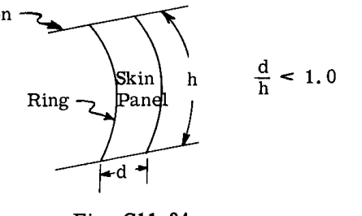

Fig. C11.34

ロンジロンシステムでは、フレームは外板およびロンジロンに取り付けられており、「フローティング」リングは存在しない。

NACA のデータおよび設計方法の大部分は、ストリンガーシステムに関するものである。本書で紹介するロンジロンシステムの設計方法は、Ref. (3) や、Chance-Vought Aircraft Corp. での調査およびテストプログラムの結果から発展したものである。これらの後者の検証は、ストリンガーシステムのものとはいくつかの点で異なっている。主な課題は、いずれのシステムにおいても、対角引張の角度を決定することである。これがわかれば、対角引張応力のすべてが決定される。

まずストリンガーシステムについて説明し、次にロンジロンシステムについて説明する。基本的なアプローチは、平面ウェブビームの場合と類似している。

## C11.32 対角引張におけるストリンガーシステムの解析

対角引張効果を計算する前に、加えられた荷重による構造内部の一次荷重を決定する必要がある。これは Chapter A20 で議論されているように行うことができる。通常、Art. A20.2-A20.5 のように、ストリンガーの軸荷重を決定するために工学的な曲げ理論を使用することができる。さまざまな外板パネルにおけるせん断流は、A20.6-A20.8 のように決定できる。ストリンガー構造の場合、必要に応じて、ストリンガー間の外板パネルが湾曲しているのではなく、平らであると仮定することにより、外板せん断流のより正確な決定を行うことができる。これは、座屈後のパネルが、Fig. C11.30a に示すように、非フローティングリングに隣接する部分を除いて、実際に平らになり、多角形の断面形状を与えるためである。

これにより、対角引張効果を評価することができる。

### 1. 外板パネルの臨界座屈応力の決定

純せん断および圧縮応力下における湾曲パネルの座屈強度は、Chapter C9 で扱われている。座屈せん断応力 $F_{s_{\text{Cr}}}$ の方程式は、以下の通りである。

$$F_{s_{\text{Cr}}} = \frac{\pi^2 \eta k_s E}{12(1 -
u_e^2)} \left(\frac{t}{b}\right)^2$$

ここで、 $k_s$ を決定する際には、通常、単純支持が保守的に仮定される。

実用的な構造物のように曲げとせん断を同時に受ける場合、軸荷重（およびひずみ）が存在すると、状況はより複雑になる。Chapter C9 で議論されているように、圧縮応力がせん断応力と同時に存在すると、圧縮がない場合よりも低いせん断値でパネルが座屈する。引張応力とせん断応力が同時に存在する場合、パネルは座屈前により大きなせん断応力に耐えることができる。実際、比較的少量の引張応力が存在することで、パネルがせん断座屈するのを完全に防ぐことができる。

軸応力、特に圧縮応力が存在する場合、実際のせん断座屈応力を決定することが重要である。その理由は、これが対角引張係数 $k$ 、およびそれに続く $k$ の影響を受けるすべての応力に影響を与えるためである。

まず、せん断応力 $f_s$ と圧縮応力 $f_c$ を受けるせん断パネルを考える。Ref. (5) の NACA において、このように荷重を受けただ円湾曲パネルは、次の相互作用公式に従って座屈することが実験的に実証されている。

$$\frac{f_c}{F_{C_{\text{Cr}}}} + \left(\frac{f_s}{F_{S_{\text{Cr}}}}\right)^2 = 1.0 \qquad \text{---(71)}$$

ここで、 $F_{C_{\text{Cr}}}$ および $F_{S_{\text{Cr}}}$ は、それぞれ純圧縮および純せん断に対する臨界パネル座屈応力である。Chapter C9 より、端部圧縮を受ける湾曲シートパネルの座屈応力は、次の式で与えられる。

$$F_{C_{\text{Cr}}} = \frac{\pi^2 \eta k_c E}{12(1 -
u_e^2)} \left(\frac{t}{b}\right)^2$$

任意の特定のパネルに対して、以下のように置く。

$$\frac{F_{C_{\text{Cr}}}}{F_{S_{\text{Cr}}}} = A \quad (\text{定数}) \qquad \text{---(72)}$$

したがって、

$$F_{C_{\text{Cr}}} = A F_{S_{\text{Cr}}}$$

また、検討対象の任意の荷重条件に対して、パネルの中央（座屈前）における $f_c \left(= \frac{Mz}{I}\right)$ および $f_s$ （事前に決定済み）を計算することができる。これらの応力は、座屈が発生するまで、互いに一定の比率を維持する。座屈発生後は、圧縮応力はそれ以上増加しない。したがって、次のように書くことができる。

$$\frac{f_c}{f_s} = B \qquad \text{---(73)}$$

または $f_c = B f_s$

これらの公式を $F_{C_{\text{Cr}}}$ および $f_c$ について相互作用公式 (71) に代入すると、以下が得られる。

$$\frac{B f_s}{A F_{S_{\text{Cr}}}} + \left(\frac{f_s}{F_{S_{\text{Cr}}}}\right)^2 = 1.0$$

この $f_s$ に関する二次方程式を解くと、以下が得られる。

$$f_s = F_{S_{\text{Cr}}} \left[ \frac{-\frac{B}{A} + \sqrt{\left(\frac{B}{A}\right)^2 + 4}}{2} \right] \qquad \text{---(74)}$$

ここで、 $f_s$ は圧縮応力の存在によりパネルが実際に座屈するときのせん断応力である。この応力を $f_{s_{\text{Cr}}}$ と呼び、大括弧内の式を $R_c$ と呼ぶ。

$$f_{s_{\text{Cr}}} = F_{S_{\text{Cr}}} R_c \qquad \text{---(75)}$$

ここで、 $R_c$ は圧縮応力が存在するとき、常に 1.0 未満である。

ここで、 $F_{S_{\text{Cr}}}$ および $F_{C_{\text{Cr}}}$ は前述の通りである。

引張応力 $f_t$ が存在するときにパネルが座屈するせん断応力 $f_s$ は、式 (76) から直接解くことができる。

$$\frac{f_{s_{\text{Cr}}}}{F_{S_{\text{Cr}}}} = 1.0 + \frac{f_t}{2 F_{C_{\text{Cr}}}} \qquad \text{---(77)}$$

または、

$$f_{s_{\text{Cr}}} = \left(1.0 + \frac{f_t}{2 F_{C_{\text{Cr}}}}\right) F_{S_{\text{Cr}}} \qquad \text{---(78)}$$

式 (78) の括弧内の式を $R_T$ と呼ぶと、以下が得られる。

$$f_{s_{\text{Cr}}} = F_{S_{\text{Cr}}} R_T \qquad \text{---(79)}$$

引張応力が存在する場合、 $R_T$ は常に 1.0 より大きいため、実際のせん断座屈応力は常に純せん断荷重のみに対する $F_{S_{\text{Cr}}}$ よりも大きくなる。(78) の括弧内の項を調べると、引張応力が $F_{C_{\text{Cr}}}$ の数倍になると、 $f_{s_{\text{Cr}}}$ の値は $F_{S_{\text{Cr}}}$ の数倍になることがわかる。したがって、 $f_t$ が十分に大きい場合、大きなせん断応力が存在しても座屈は発生しない。

### 2. 対角引張係数 $k$

次のステップは、対角引張係数 $k$ の決定である。これは、前述のように、 $\frac{f_s}{f_{s_{\text{Cr}}}}$ の関数であり、圧縮応力または引張応力が存在するかどうかに応じて、以下のようになる。

$$f_{s_{\text{Cr}}} = F_{S_{\text{Cr}}} R_c \quad \text{または} \quad f_{s_{\text{Cr}}} = F_{S_{\text{Cr}}} R_T$$

湾曲パネルの場合、多くのテストデータ（Ref. (3)）から決定された $k$ の公式は、以下の経験的関係式である。

$$k = \tanh \left[ \left(0.5 + 300 \frac{t d}{R h}\right) \log_{10} \frac{f_s}{f_{s_{\text{Cr}}}} \right] \qquad \text{---(80)}$$

$$R = \text{曲率半径}$$

ただし、以下の補助ルールを伴う。

1. $\frac{d}{h} > 2$ の場合は、2 のみを使用する。
2. $h > d$ の場合は、 $\frac{d}{h}$ を $\frac{h}{d}$ に置き換え（「ロンジロン」システム）、この場合に $\frac{h}{d} > 2$ であれば 2 のみを使用する。

公式から $k$ を計算するよりも、Fig. C11.19 から容易に得ることができる。

### 3. ストリンガーの荷重、応力、およびひずみ

平面ウェブシステムの場合と同様に、全ストリンガー荷重は、加えられた曲げモーメントおよび/または軸荷重による一次軸荷重 $P_p$ と、対角引張によって誘発される荷重 $P_{\text{D.T.}}$ から構成される。

$$P_{\text{STR}} = P_p + P_{\text{D.T.}} \qquad \text{---(81)}$$

$P_p$ は Chapter A20.2-A20.5 と同様に決定される。 $P_{\text{D.T.}}$ は、平面ウェブビームのフランジの場合と同様に、端部フレームにおける座屈外板の「引っ張り」から決定される。

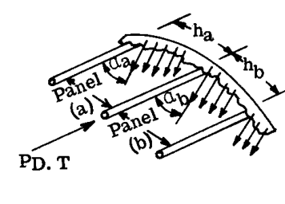

Fig. C11.35

Fig. C11.35 に示すように、 $P_{\text{D.T.}}$ は、一方の側をパネル “a”、他方の側をパネル “b” で囲まれたストリンガーにおける対角引張荷重である。パネル (a) の幅を $h_a$ 、パネル (b) の幅を $h_b$ とする（等間隔のストリンガーの場合、当然 $h_a = h_b$ である）。パネル (a) のせん断流を $q_a$ 、パネル (b) のせん断流を $q_b$ とする。このとき、以下のように書くことができる。

$$P_{\text{D.T.}} = \frac{k_a q_a h_a \cot \alpha_a}{2} + \frac{k_b q_b h_b \cot \alpha_b}{2} \qquad \text{---(82)}$$

計算をより単純に保つために、ある程度の不正確さを許容し、それぞれの項について平均値（ $\frac{h_a + h_b}{2}$ 、 $\frac{q_a + q_b}{2}$ など）を使用すると、以下が得られる。

$$P_{\text{D.T.}} = k q h \cot \alpha \qquad \text{---(83)}$$

これは「平均」荷重であり、ストリンガーが密に配置されている場合、特に予備設計においては十分である。したがって、全ストリンガー荷重は、(81) と (83) から以下のようになる。

$$P_{\text{STR}} = P_p + k q h \cot \alpha$$

ここで、 $\alpha$ 以外のすべての項は既知である。

ストリンガー応力は、右辺の項をそれぞれの有効断面積で割ることによって得られる。

$$f_{\text{STR}} = \frac{P_{\text{STR}}}{A} = \frac{P_p}{A_{ep}} + \frac{k q h \cot \alpha}{A_{e_{\text{D.T.}}}}$$

1. $A_{ep}$ は、Chapter A20 と同様に、一次荷重を決定する際に使用される、ストリンガーと外板の総有効断面積である。 $P_p$ が引張である場合、面積は $h t$ に等しく、パネルは完全に有効である。
2. $A_{e_{\text{D.T.}}} = A_{\text{STR}} + 0.5 h t (1 - k) R_{c,T}$ （Ref. (3) 参照） $\qquad \text{---(84)}$

$R_{c,T}$ は、軸方向の圧縮または引張が存在するかどうかに依存する。また、 $k$ および $R_c$ または $R_T$ は、ストリンガーの各側のパネルに対する平均値である。したがって、以下のように書くことができる。

$$f_{\text{STR}} = \frac{P_p}{A_{\text{STR}} + A_{e_{\text{SKIN}}}} + \frac{k q h \cot \alpha}{A_{\text{STR}} + 0.5 h t (1 - k) R_{c,T}}$$

または、

$$f_{\text{STR}} = \frac{P_p}{A_{\text{STR}} + A_{e_{\text{SKIN}}}} + \frac{k f_s \cot \alpha}{\frac{A_{\text{STR}}}{h t} + 0.5 (1 - k) R_{c,T}} \qquad \text{---(85)}$$

ここで、右辺の $\alpha$ 以外のすべての項は既知である。

全ストリンガーひずみは、以下のようになる。

$$\epsilon_{\text{STR}} = \frac{f_{\text{STR}}}{E} \qquad \text{---(86)}$$

$f_{\text{STR}}$ が比例限度応力より大きい場合、または降伏応力の近傍にある場合、 $E$ は定数ではなく、応力-ひずみ線図を使用して $f_{\text{STR}}$ から $\epsilon$ を直接読み取る必要がある。この場合も、 $f_{\text{STR}}$ 、したがって $\epsilon_{\text{STR}}$ は、 $\alpha$ が（後で）決定されるまで決定できない。

ストリンガーには、内側に曲げる、または「たわませる」傾向のある二次荷重も作用する。これは、張られた外板がストリンガーの両側で平らに引っ張られることによって引き起こされる。したがって、Fig. C11.30 のように、ストリンガーを内側に引っ張る外板の対角引張荷重の内向き成分が存在する。この荷重は単純な等分布荷重ではなく、ストリンガーの中央で最大になり、支持部で小さくなる。Ref. (3) は、この荷重の影響を、ストリンガーに二次曲げモーメントを発生させるものとして考慮することを推奨しており、以下のように表される。

$$M_{\text{STR}} = \frac{f_s h t d^2 k \tan \alpha}{24 R} \qquad \text{---(87)}$$

$$R = \text{曲率半径}$$

これは、中央およびリング支持部における「ピーク」モーメントを表している。これにより、中央ではストリンガーの内側に引張が発生し、支持部ではストリンガーの内側に圧縮が発生する。推奨される $M_{\text{STR}}$ の値は多くのテスト測定の結果であり、したがって半経験的な性質のものである。

### 4. リングにおける応力およびひずみ

リングには2つのタイプがあり、外板に取り付けられているものと、外板に取り付けられておらず「フローティングリング」と呼ばれ、ストリンガーを支持し、したがってストリンガーのみから荷重を受けるものである。

外板に取り付けられたリングには、通常、ストリンガーを通すための「ノッチ」が設けられている。ストリンガーは、何らかのせん断クリップ配置によって、これらのリングに局所的に取り付けられている。リングは内向きの荷重を受け、これにより「フープ圧縮」状態になる。これらの荷重は、ストリンガーおよび外板から伝達される。ストリンガーは、前述のように、また Fig. C11.30 に示すように、外板によって内側に引っ張られ、今度は支持リングを内側に押す。外板は、リング部において平らではないため、リングを内側に引っ張る。これらすべての結果として、本質的には Ref. (3) によれば、純ねじりを受ける円筒の場合のリングにおけるフープ圧縮応力となる。これは、荷重が均一に分布した内向きの半径方向荷重とほぼ等価であるためである。この場合、半径方向荷重は、リングに沿って1インチあたり以下のようにとることができる。

$$p_{\text{RG}} = \frac{f_s d t k \tan \alpha}{R_{\text{RING}}}$$

リングにおける軸方向（フープ）圧縮荷重は、以下のようになる。

$$P_{\text{RG}} = p R = f_s d t k \tan \alpha \qquad \text{---(88)}$$

リングにおける軸圧縮応力は、以下のようになる。

$$f_{\text{RG}} = \frac{P_{\text{RG}}}{A_{e_{\text{RG}}} + \text{SKIN}} = \frac{k f_s \tan \alpha}{\frac{A_{\text{RG}}}{d t} + 0.5(1 - k)} \qquad \text{---(89)}$$

ここで、右辺の $\alpha$ 以外のすべての項は既知である。

リングにおける軸方向ひずみは、以下のようになる。

$$\epsilon_{\text{RG}} = \frac{f_{\text{RG}}}{E} \qquad \text{---(90)}$$

ここで、 $f_{\text{RG}}$ 、したがって $\epsilon_{\text{RG}}$ は、 $\alpha$ が決定されるまで未知である。

純ねじり以外の荷重が加えられる場合、 $f_s$ および $k$ はパネルごとに変化し、フープ圧縮応力はリングの全周にわたって一定ではなくなる。また、座屈した外板によるストリンガー部でのパネル両側の不均等な「引っ張り」により、パネル内にいくつかの変化する二次せん断応力が発生する。

「フローティング」リングが使用される場合、ストリンガーによって集中した内向きの半径方向荷重が加えられる。これによりフープ圧縮が発生し、すべての荷重が集中するため、いくつかの曲げモーメントも発生する。当然のことながら、これらのリングには有効な外板は作用しない。軸圧縮荷重は、以下の通りである。

$$P_{\text{D.T.}} = f_s d t k \tan \alpha$$

このとき、軸圧縮応力は以下のようになる。

$$f_{\text{RG}} = \frac{k f_s \tan \alpha}{\frac{A_{\text{RG}}}{d t}} \qquad \text{---(91)}$$

ここで、右辺の $\alpha$ 以外のすべての項は既知である。

軸方向ひずみは、以下のように与えられる。

$$\epsilon_{\text{RG}} = \frac{f_{\text{RG}}}{E} \qquad \text{---(92)}$$

あるいは、当然のことながら、材料の応力-ひずみ線図から得ることもできる。

フローティングリングに発生する最大曲げモーメントは、以下のように与えられる。

$$M_{\text{RG}} = \frac{k f_s t h^2 d \tan \alpha}{12 R} \qquad \text{---(93)}$$

$$R = \text{曲率半径}$$

これはストリンガーとの接合部で発生する。リング内のストリンガー間の中間点には、その半分の大きさの二次モーメントが発生する。

### 5. 外板パネルにおけるひずみ

外板パネルにおけるひずみは、Ref. (3) において以下のように与えられている。

$$\epsilon = \frac{f_s}{E} \left[ \frac{2k}{\sin 2\alpha} + \sin 2\alpha (1 - k)(1 +
u) \right] \qquad \text{---(94)}$$

ここで、アルミニウムの場合、 $u = \text{ポアソン比} = 0.32$ であり、右辺の $\alpha$ 以外のすべての項は既知である。Fig. C11.36 は $\epsilon$ の計算に役立ち、括弧内の項の値を与える。

### 6. $\alpha$ の決定

ストリンガーシステム（ $d > h$ ）の場合、Ref. (3) は、 $\alpha$ がストリンガーひずみ、リングひずみ、およびウェブ（外板パネル）ひずみと、次の公式によって関連していることを示している。

$$\tan^2 \alpha = \frac{\epsilon - \epsilon_{\text{STR}}}{\epsilon - \epsilon_{\text{RG}} + \frac{1}{24} \left(\frac{h}{R}\right)^2} \qquad \text{---(95)}$$

$$R = \text{曲率半径}$$

ここで、 $\epsilon$ は引張ひずみ（ $+$ ）であり、 $\epsilon_{\text{RG}}$ および $\epsilon_{\text{STR}}$ は圧縮に対して負の部材として入力され、したがって $\epsilon$ に加算される。

$\alpha$ は、 $\epsilon$ 、 $\epsilon_{\text{STR}}$ 、および $\epsilon_{\text{RG}}$ に対する3つの事前の公式を使用し、上記の公式 (95) でチェックすることにより、逐次近似によって決定される。すなわち、

1. $\alpha$ の値を仮定する。
2. この仮定した $\alpha$ の値を使用して、 $\epsilon$ 、 $\epsilon_{\text{RG}}$ 、および $\epsilon_{\text{STR}}$ を決定する。
3. $\epsilon$ 、 $\epsilon_{\text{RG}}$ 、および $\epsilon_{\text{STR}}$ を $\tan^2 \alpha$ の公式に代入し、新しい $\alpha$ の値を得る。
4. 「収束」した値が得られるまで、必要に応じてステップ (1) から (3) を（例えば3回）繰り返す。

外板に取り付けられたリングが使用されている場合、ステップ (2) における $\epsilon_{\text{RG}}$ は、 $f_{\text{RG}}$ に (89) を使用して (90) から得られる。「フローティング」リングが使用されている場合、 $\epsilon_{\text{RG}}$ は $f_{\text{RG}}$ に (91) を使用して (92) から得られる。

$\alpha$ が決定されると、(95) における $\alpha$ の最終チェックのためにひずみ $\epsilon_{\text{STR}}$ および $\epsilon_{\text{RG}}$ を得るために使用されたストリンガー応力およびリング応力が既知となる。ストリンガーにおける曲げモーメントは (87) から計算でき、使用されている場合はフローティングリングにおける曲げモーメントを (93) から計算できる。

### 7. リベットにおける荷重

計算すべき残りの内部荷重は、リベットに作用する荷重のみである。これらは2つのタイプに分類される。

1. 外板の面内に作用し、他の接合された外板と同様に、リベット接合部においてせん断または支圧破壊を引き起こそうとする一次荷重が存在する。
2. リベット頭部を「飛び出させ」ようとする、あるいは外板をリベット頭部の周囲に引っ張り上げようとする「こじ開け（プライング）」力も存在する。後者は、特に皿沈め（カウンタサンク）またはディンプル外板と丸頭リベットが使用され、リベット径が小さすぎるかリベット間隔が大きすぎる場合に発生する可能性がある。これらは「二次」荷重である。

一次リベット荷重は、外板が接合されているときには常に発生し、これは通常、ストリンガーまたはリングに沿っているが、必ずしもそうとは限らない。これらの荷重は、開口部や「切り欠き」などのように、ストリンガーやリングで外板パネルが終了し、座屈を防ぐためにダブラーで補強されていない場合にも存在する。

ストリンガーに平行な継手（スプライス）において、リベット線に沿った1インチあたりの荷重は、平面ウェブビームについて議論されたものと同様の効果による。それは、以下の通りである。

$$\text{Load/inch} = f_{st} t \left[ 1 + k \left( \frac{1}{\cos \alpha} - 1 \right) \right] \qquad \text{---(96)}$$

リングに沿った継手（または開口部）（垂直方向の継手）において、荷重は以下の通りである。

$$\text{Load/inch} = f_s t \left[ 1 + k \left( \frac{1}{\sin \alpha} - 1 \right) \right] \qquad \text{---(97)}$$

いずれの場合も、関連するパネルが（継手の両側で）非座屈である場合、 $k = 0$ となり、1インチあたりの荷重は座屈していないウェブの場合と同じになることに注意されたい。パネルが非座屈、あるいは座屈の程度が小さくなるように作られるのは、リベットではなくエッジ部材の荷重を「軽減」するために、通常、「切り欠き」や開口部の周囲のみである（Art. C11.29 参照）。

第2のタイプのリベット荷重であるこじ開け荷重は、いかなる公式によっても決定できない。Ref. (3) は、以下のような任意の基準を使用することを推奨している。リベットと外板の組み合わせの引張強度 $P_T$ は、以下の式で与えられる数値と同等以上に大きくあるべきである。

$$\text{1インチあたりの } P_T = 0.22 t F_{tu} \qquad \text{---(98)}$$

ここで、 $F_{tu}$ は、使用されている外板またはウェブ材料の引張強さ（終局引張応力）である。

$P_T$ は、通常、皿沈め（フラッシュ）取り付けにおいて最も重要である。これを得るための助けとして、Fig. C11.37a および Fig. C11.37b は、さまざまなリベットのタイプおよびサイズに対する引張強度に関する情報を提供している。

## C11.33 許容応力（および相互作用）

### 1. ストリンガー

ストリンガーおよびリングにおける基本的な荷重（および応力）に2つのタイプ（一次荷重と、対角引張効果による荷重）があるのと同様に、局所破壊に対する許容応力にも2つのタイプがある。したがって、適切な強度を予測するために、相互作用公式が使用される。これは、ストリンガーに対して以下のようになる。

$$\frac{f_p}{F_{cc}} + \frac{f_{\text{STMAX}}}{F_{\text{ST}}} \le 1.0 \qquad \text{---(99)}$$

ここで、

- $f_p$ = 加えられた荷重によるストリンガー応力。これは式 (85) の右辺の第1項である。
- $F_{cc}$ = ストリンガーの許容クリップリング応力。Chapter C7 と同様にして得られる。

$$\begin{aligned}
f_{\text{STMAX}} = f_{\text{ST}} \times \frac{f_{\text{STMAX}}}{f_{\text{ST}}}
\end{aligned}$$

$f_{\text{ST}}$ は、式 (85) の右辺の第2項である。

$\frac{f_{\text{STMAX}}}{f_{\text{ST}}}$ は Fig. C11.21 から得られる比率である。これは平面ウェブビームの議論において説明されている。

$F_{\text{ST}}$ = ストリンガーに対する「強制クリップリング」（対角引張効果）許容応力。平面ウェブビームのアップライトの場合と同様に、Fig. C11.38 から得られるか、または公式（ $F_{\text{RG}}$ および $t_{\text{RG}}$ に対しても同様）から計算される。

24ST 材料の場合：

$$F_{\text{ST}} = 26,000 k^{2/3} \left( \frac{t_{\text{STR}}}{t_{\text{WEB}}} \right)^{1/3}$$

75ST 材料の場合、C11.22 に示されている制限を適用して：

$$F_{\text{ST}} = 32,500 k^{2/3} \left( \frac{t_{\text{STR}}}{t_{\text{WEB}}} \right)^{1/3}$$

（全軸方向ストリンガー応力は、支持リング付近の領域においては $f_p + f_{\text{ST}}$ であり、支持部間の中央においては $f_p + f_{\text{STMAX}}$ となる。）

式 (87) の曲げモーメント $M_{\text{STR}}$ によるストリンガー応力は、計算して $f_p$ に適切に加算することができる。

Ref. (3) はまた、ストリンガーを、支持リングにおいて完全に固定され、応力 $f_{\text{STR}}$ を受ける柱（コラム）としてチェックすることを提案している。ストリンガーの中央に存在する曲げモーメントにより、梁-柱（ビームコラム）作用を考慮する必要がある。これは、議論されたモーメントを発生させるいくつかの有効な荷重を使用するか、あるいは柱座屈応力を上回るいくつかの追加の安全余裕を持たせることによって行うことができる。

### 2. リング

リングは、ストリンガーと性質が類似した許容応力を持つ。相互作用公式は、以下の通りである。

$$\frac{f_p}{F_{cc}} + \frac{f_{\text{RGMAX}}}{F_{\text{RG}}} \le 1.0 \qquad \text{---(100)}$$

これは、外板に取り付けられたリングの場合である。

$f_p$ は、（隔壁解析が示すような）対角引張場以外の荷重を負担するリングによる応力である。 $F_{\text{RG}}$ はリングに対する許容強制クリップリング応力であり、スチフナ（Fig. C11.38）に対するものと同様の方法で得られる。

$$f_{\text{RGMAX}} = f_{\text{RG}} \times \frac{f_{\text{RGMAX}}}{f_{\text{RG}}}$$

は、スチフナについて議論されたものと同様の方法で得られる。これはスチフナ間の中間点のリングにおいて発生する。

$F_{cc}$ はリングに対する「通常の」許容クリップリング応力である。もし $f_{\text{RG}} > F_{cc}$ であれば、 $F_{\text{RG}}$ の代わりに $F_{cc}$ を使用する。

フローティングリングは、外板による強制クリップリングを受けないため、フープ圧縮荷重およびそれに伴う曲げモーメントによる応力に対して、通常の式 (91) および (93) を用いてチェックされる。相互作用公式は、以下の通りである。

$$\frac{f_{\text{RG}} + f_M}{F_{cc}} - 1 \le 0 \qquad \text{---(101)}$$

$f_{\text{RG}}$ はストリンガー接合部間において一定の応力であり、外板に取り付けられたリングのように最大ピークを持たない。

### 3. 一般不安定性

ストリンガーおよび外板に対する一般不安定性のチェックは、Fig. C11.39 に提示されている経験的基準から行うことができる。これは、Ref. (7) および Ref. (3) の推奨事項とテストデータから得られたものである。許容値は純ねじりテストに基づいている。構造の妥当性は、以下によってチェックされる。

$$\frac{f_s}{F_{S_{\text{INST}}}} - 1 \le 0 \qquad \text{---(102)}$$

十分な安全余裕（M.S. $\ge 0.15$ ）を維持することが推奨される。基準はこれらの仮定の下で得られたものであるため、Fig. C11.39 における断面回転半径は、外板の全幅がそれぞれストリンガーまたはリングと連動して作用し、外板は平らであると仮定して算出されるべきである。

### 4. 外板（またはウェブ）の許容応力

Ref. (3) は、非皿沈め締結部に対する、ウェブまたは外板における許容応力を以下のようにとることを推奨している。

$$\begin{aligned}
f_{S_{\text{ALL}}} = f^*_{S_{\text{ALL}}} (0.65 + \Delta) \qquad \text{---(103)}
\end{aligned}$$

ここで、

$$\Delta = 0.3 \tanh \frac{A_{\text{RG}}}{d t} + 0.1 \tanh \frac{A_{\text{ST}}}{h t}$$

$\Delta$ は、より容易には Fig. C11.40 から読み取ることができる。 $f^*_{S_{\text{ALL}}}$ は、Fig. C11.41a から $\tau_{\text{PDT}}$ を得た後、Fig. C11.41b または Fig. C11.41c から得られる。Chance-Vought Aircraft Corp. によるテストデータは、許容ウェブ応力を単に Fig. C11.42 から読み取ることができることを示している。いずれの場合も、許容値はパネルにおける総応力 $f_s$ に適用される。リベット穴間の正味せん断応力は、材料の終局せん断応力 $F_{su}$ まで負担させることができる。